# Gradient descent

## *exemplos*

> Henrique Aparecido Laureano [[Lattes](http://lattes.cnpq.br/2224901552085090), [LEG GitLab](http://git.leg.ufpr.br/u/laureano), [GitLab](https://gitlab.c3sl.ufpr.br/u/hal11)]

### Março de 2016

> De forma intuitiva o algoritmo de gradiente descendente é um método para encontrar o mínimo de uma função de forma iterativa

## Batch

$$f(x, y) = x^{2} + 2 y^{2}$$

```r
library(animation)
grad.desc()[1:3]
```

```
$par
            x             y
-0.0675851986  0.0009735557

$value
          x
0.004569655

$iter
[1] 36
```

[interactive chart not shown]

$$f(x, y) = \sin(0.5x^{2} - 0.25y^{2} + 3) \cos(2x + 1 - e^{y})$$

*Aumentando o tamanho do passo, argumento* `gamma`

O *default* é 0.05

```r
fn <- function(x, y) sin(.5*x**2 - .25*y**2 + 3) * cos(2*x + 1 - exp(y))
grad.desc(fn, init = c(-1, .5), gamma = .3, tol = 1e-04)[1:3]
```

```
$par
         x          y
2.26956698 0.07494521

$value
        x
0.1617829

$iter
[1] 50
```

[interactive chart not shown]

Referência: [Demonstration of the Gradient Descent Algorithm](http://vis.supstat.com/2013/03/gradient-descent-algorithm-with-r/)

### Construindo um exemplo

```r
x0 <- rep(1, 5) ; x1 <- 1:5
x <- as.matrix(cbind(x0, x1))

y <- as.matrix(c(3, 7, 5, 11, 14))
m <- nrow(y)

x.scaled <- x
x.scaled[ , 2] <- (x[ , 2] - mean(x[ , 2])) / sd(x[ , 2])
# essa padronização aumenta a velocidade de convergência do algoritmo

solve(t(x) %*% x) %*% t(x) %*% y
```

```
   [,1]
x0  0.2
x1  2.6
```

```r
lm(y ~ x[ , 2])$coefficients
```

```
(Intercept)      x[, 2]
        0.2         2.6
```

```r
solve(t(x.scaled) %*% x.scaled) %*% t(x.scaled) %*% y
```

```
       [,1]
x0 8.000000
x1 4.110961
```

```r
lm(y ~ x.scaled[ , 2])$coefficients
```

```
  (Intercept) x.scaled[, 2]
     8.000000      4.110961
```

**Hipótese linear**

$$h_{\theta} (x) = \theta_{0} + \theta_{1} x$$

A ideia é minimizar a soma de quadrados dos erros, que no contexto de *machine learning* é representada pela **função custo**

$$J(\theta_{0}, \theta_{1}) = \frac{1}{2m} \sum_{i=1}^{m} (h_{\theta} (x^{(i)}) - y^{(i)})^{2}$$

Para $j = 1$ e $j = 0$ o **algoritmo do gradiente descendente** é

*Repetir até convergência:*

$$\theta_{j} := \theta_{j} - \alpha \frac{\partial}{\partial \theta_{j}} J(\theta_{0}, \theta_{1})$$

Onde

$$\frac{\partial}{\partial \theta_{j}} J(\theta) = \frac{1}{m} \sum_{i=1}^{m} (h_{\theta} (x^{(i)}) - y^{(i)}) x_{j}^{(i)}$$

Dessa forma o **algoritmo do gradiente descendente** fica

*Repetir até convergência:*

$$\theta_{j} := \theta_{j} - \alpha \frac{1}{m} \sum_{i=1}^{m} (h_{\theta} (x^{(i)}) - y^{(i)}) x_{j}^{(i)}$$

*Esse código não é eficiente, mas é intuitivo*

```r
# definindo a derivada da função custo em forma matricial
grad <- function(x, y, theta){
  gradient <- (1/m)*( t(x) %*% ( (x %*% t(theta)) - y ) )
  return(t(gradient))}

# definindo o algoritmo
grad.descent <- function(x, maxit){
  theta <- matrix(c(0, 0), nrow = 1)
  alpha = .05 # taxa de aprendizado padrão
  for(i in 1:maxit){
    theta <- theta - alpha*grad(x, y, theta)}
  return(theta)}

# objetivo: 0.2 e 2.6
grad.descent(x, 100)
```

```
            x0       x1
[1,] 0.4067232 2.542741
```

```r
grad.descent(x, 500)
```

```
            x0      x1
[1,] 0.2069313 2.59808
```

```r
grad.descent(x, 1000)
```

```
            x0       x1
[1,] 0.2000994 2.599972
```

```r
# objetivo: 8 e 4.110961
grad.descent(x.scaled, 100)
```

```
           x0       x1
[1,] 7.952636 4.041608
```

```r
grad.descent(x.scaled, 500) # convergência obtida mais rapidamente
```

```
     x0       x1
[1,]  8 4.110961
```

#### **Custo e intuição de convergência**

> Tipicamente nós iteramos o algoritmo até que a mudança na função custo (como os valores de $\beta_{0}$ e $\beta_{1}$ atualizados) seja extremamente pequena, i.e., $c$. $c$ pode ser definido como o critério de convergência. Se $c$ não é atingido após um dado número de iterações, você pode aumentar as iterações ou mudar a taxa de aprendizado $\alpha$ para acelerar a convergência

```r
beta <- grad.descent(x, 1000)

# definindo a hipótese linear
h <- function(xi, b0, b1) b0 + b1*xi

# definindo a função custo
cost <- t(mat.or.vec(1, m))
for(i in 1:m) cost[i, 1] <- (1/(2*m))*(h(x[i, 2], beta[1, 1], beta[1, 2]) - y[i, ])**2

(totalCost <- colSums(cost))
```

```
[1] 1.24
```

```r
cost1000 <- totalCost

# aumentando o número de iterações para 1001
beta <- grad.descent(x, 1001)

cost <- t(mat.or.vec(1, m))
for(i in 1:m) cost[i, 1] <- (1/(2*m))*(h(x[i, 2], beta[1, 1], beta[1, 2]) - y[i, ])**2

cost1001 <- colSums(cost)

# essa diferença atende à seus critérios de convergência?
cost1000 - cost1001
```

```
[1] 1.515144e-11
```

Referência: [Regression via Gradient Descent in R](http://econometricsense.blogspot.com.br/2011/11/regression-via-gradient-descent-in-r.html)

### Mais um exemplo

```r
x <- runif(1000, -5, 5) ; y <- x + rnorm(1000) + 3
lm(y ~ x)$coefficients
```

```
(Intercept)           x
  2.9653794   0.9966173
```

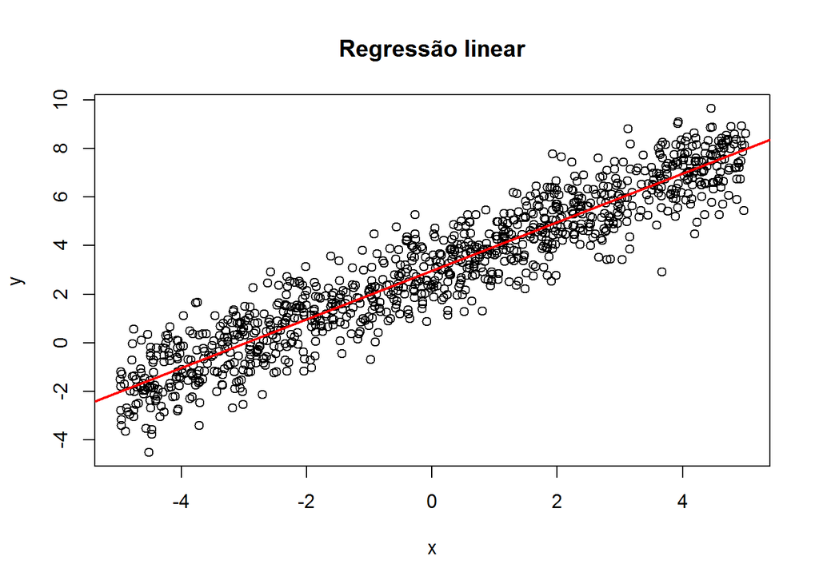

```r
plot(y ~ x, main = "Regressão linear") ; abline(lm(y ~ x), col = 2, lwd = 2)
```

*Outra maneira de programar o algoritmo de gradiente descendente*

```r
# função custo
cost <- function(X, y, theta) sum((X %*% theta - y)**2) / (2*length(y))

# taxa de aprendizado e número limite de iterações
alpha <- .01 ; num_iters <- 1000

# armazenando o histórico
cost_history <- double(num_iters)
theta_history <- list(num_iters)

# inicializando os coeficientes
theta <- matrix(c(0, 0), nrow = 2)

# inserindo uma coluna de 1's para o intercepto
X <- cbind(1, matrix(x))

# gradiente descendente
for(i in 1:num_iters){
  error <- X %*% theta - y
  delta <- t(X) %*% error / length(y)
  theta <- theta - alpha * delta
  cost_history[i] <- cost(X, y, theta)
  theta_history[[i]] <- theta}

theta
```

```
          [,1]
[1,] 2.9652511
[2,] 0.9966184
```

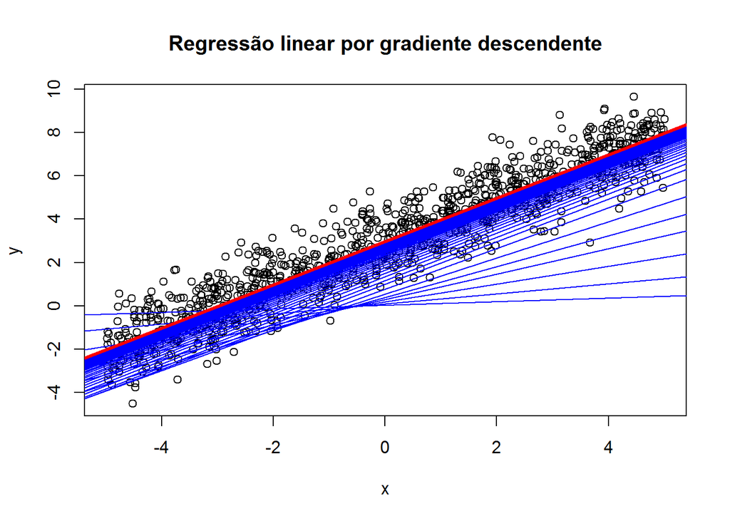

```r
# objetivo: 2.9653794 e 0.9966173

plot(y ~ x, main = "Regressão linear por gradiente descendente")
for(i in c(1, 3, 6, 10, 14, seq(20, num_iters, 10))) abline(theta_history[[i]], col = "blue")
abline(theta, col = 2, lwd = 3)
```

*E como a função custo decai?*

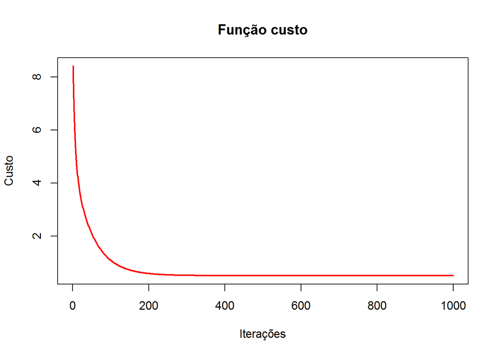

```r
plot(cost_history, type = "l"
     , col = 2, lwd = 2, main = "Função custo", xlab = "Iterações", ylab = "Custo")
```

Referência: [Linear regression by gradient descent](http://digitheadslabnotebook.blogspot.com.br/2012/07/linear-regression-by-gradient-descent.html)

## Stochastic

*A diferença no algoritmo de gradiente descendente estocástico é que aqui é usada apenas uma observação aleatória da base em cada iteração*

> Quando a base de dados é muito grande esse algoritmo é útil, contudo, as estimativas obtidas com ele não são tão boas quanto a solução ótima global, já que apenas uma observação é usada por iteração

```r
x <- runif(1000000, 1, 100) ; y <- 5 + 4*x
lm(y ~ x)$coefficients
```

```
(Intercept)           x
          5           4
```

```r
# gds: gradiente descendente estocástico
gds <- function(x, y, b0, n, alpha){
  beta <- as.matrix(cbind(rep(b0[1], n), rep(b0[2], n)))
  for(i in 2:n){
    m <- length(x)
    sample_num <- sample.int(m, 1)
    xx <- x[sample_num]
    yy <- y[sample_num]
    beta[i, 1] <- beta[i-1, 1] - alpha*(beta[i-1, 1] + beta[i-1, 2]*xx - yy)
    beta[i, 2] <- beta[i-1, 2] - alpha*(xx*(beta[i-1, 1] + beta[i-1, 2]*xx - yy))}
  return(beta)}

b0 <- c(0, 0)

beta <- gds(x, y, b0, 1000000, .00005)

beta[1e06, ]
```

```
[1] 4.999974 4.000000
```

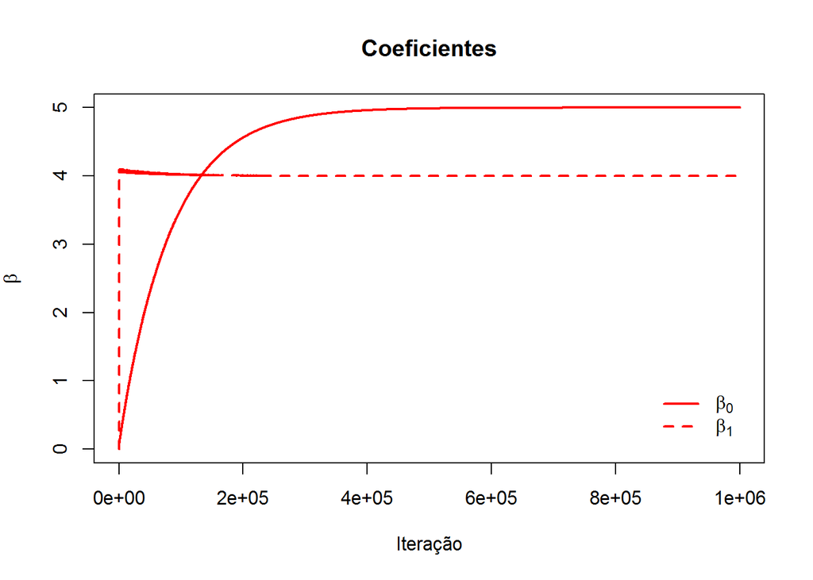

```r
plot(beta[1:1000000, 1], type = "l"
     , col = 2, lwd = 2, xlab = "Iteração", ylab = expression(beta), main = "Coeficientes")
lines(beta[1:1000000, 2], col = 2, lwd = 2, lty = 2)
legend(85e04, 1, bty = "n", lty = c(1, 2), lwd = 2, col = 2
       , legend = c(expression(beta[0]), expression(beta[1])))
```

Referência: [Stochastic gradient descent to find least square in linear regression](https://qizeresearch.wordpress.com/2014/05/23/stochastic-gradient-descent-to-find-least-square-in-linear-regression/)

## Boosting

*Aqui $h(x_{i})$ é atualizado com o resíduo de um modelo ajustado, onde esse resíduo é equivalente ao negativo do gradiente*

É escolhido um chute inicial, $h(x_{i})^{(0)}$, é calculado o $- \partial J(y_{i}, h(x)^{(k)}) / \partial h(x_{i})^{(k)}$

E é ajustado um modelo de regressão $g(x_{i})^{(k)}$ fundamentado no negativo do gradiente

$$h(x_{i})^{(k+1)} = h(x_{i})^{(k)} + \alpha g(x_{i})^{(k)}, \quad k = 0, 1, \cdots$$

até atingir convergência

```r
library("mboost")
```

### *Exemplo*: predição de gordura corporal

```r
data("bodyfat", package = "TH.data")

lm(DEXfat ~ hipcirc + kneebreadth + anthro3a, bodyfat)$coefficients
```

```
(Intercept)     hipcirc kneebreadth    anthro3a
-75.2347840   0.5115264   1.9019904   8.9096375
```

```r
model.boost <- glmboost(DEXfat ~ hipcirc + kneebreadth + anthro3a, bodyfat)
coefficients(model.boost, off2int = TRUE)
```

```
(Intercept)     hipcirc kneebreadth    anthro3a
-75.2073365   0.5114861   1.9005386   8.9071301
```

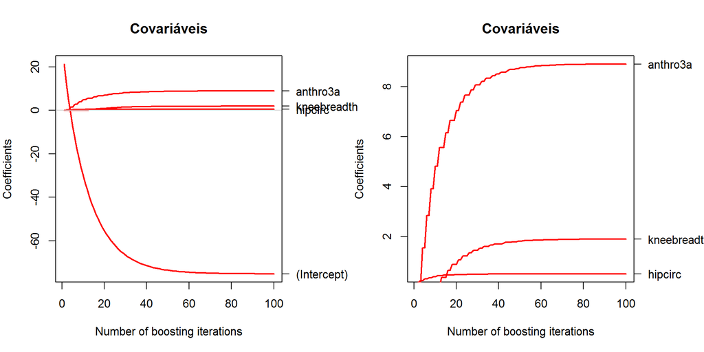

```r
par(mfrow = c(1, 2), mar = c(5, 4, 4, 5))
plot(model.boost, off2int = TRUE, col = 2, lwd = 2, main = "Covariáveis")
plot(model.boost, col = 2, lwd = 2
     , ylim = range(coefficients(model.boost, which = model.boost$basemodel[[1]]$Xnames[-1]))
     , main = "Covariáveis") ; layout(1)
```

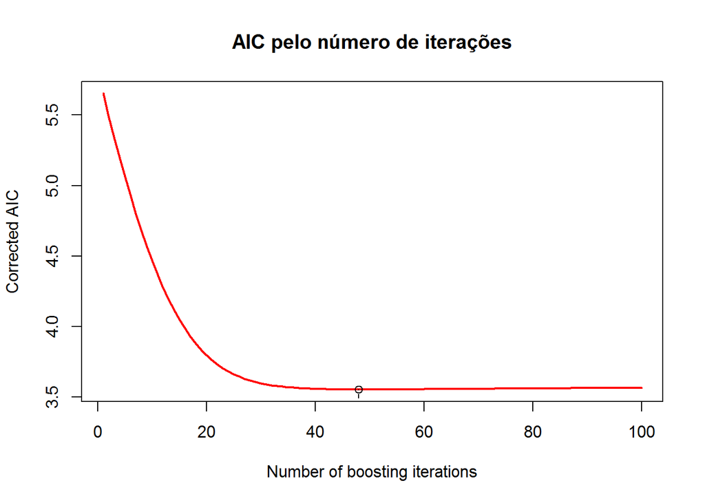

```r
plot(AIC(model.boost), col = 2, lwd = 2, main = "AIC pelo número de iterações")
```

Referência: [Model-based Boosting in R, A Hands-on Tutorial Using the R Package mboost](https://cran.r-project.org/web/packages/mboost/vignettes/mboost_tutorial.pdf)